# Portfolio optimization without leaving the tidyverse

Davis Vaughan

10/13/2017

# Setup

## Required packages

```r
# For loading tidyverse and getting data
library(tidyquant)

# For portfolio optimization
library(PortfolioAnalytics)

# For purrr parallelization
library(future)

# Also used
library(rmarkdown)

# Set ggplot theme
theme_set(theme_minimal())
```

## Get data for the Wealthfront ETFs

```r
wf_stocks <- tibble(
  wf_ticker = c("VTI", "VEA", "VWO", "VNQ", "XLE", "BND", "SCHP", "VTEB", "VIG"),
  wf_name   = c("US Stocks", "Foreign Stocks", "Emerging Markets", "Real Estate",
                "Natural Resources", "US Gov Bonds", "TIPS",
                "Muni Bonds", "Dividend Stocks")
)

wf_stocks <- tq_get(wf_stocks, from = "2000-01-01")

# Only select minimal columns
wf_stocks_minimal <- wf_stocks %>%
  select(wf_ticker, wf_name, date, adjusted)

wf_stocks_minimal
```

```
## # A tibble: 25,513 x 4
##    wf_ticker   wf_name       date adjusted
##        <chr>     <chr>     <date>    <dbl>
##  1       VTI US Stocks 2001-06-15 41.07117
##  2       VTI US Stocks 2001-06-18 40.80925
##  3       VTI US Stocks 2001-06-19 40.92361
##  4       VTI US Stocks 2001-06-20 41.35524
##  5       VTI US Stocks 2001-06-21 41.68726
##  6       VTI US Stocks 2001-06-22 41.42163
##  7       VTI US Stocks 2001-06-25 41.15535
##  8       VTI US Stocks 2001-06-26 41.04810
##  9       VTI US Stocks 2001-06-27 41.05180
## 10       VTI US Stocks 2001-06-28 41.55478
## # ... with 25,503 more rows
```

# Exploration and visualization

## Calculate returns with tidyquant

```r
# Using tq_mutate with a group_by to calculate returns for each stock in
# a tidy way
wf_stocks_returns <- wf_stocks_minimal %>%
  group_by(wf_ticker) %>%
  tq_mutate(adjusted, dailyReturn, col_rename = "daily_return")

wf_stocks_returns
```

```
## # A tibble: 25,513 x 5
## # Groups:   wf_ticker [9]
##    wf_ticker   wf_name       date adjusted  daily_return
##        <chr>     <chr>     <date>    <dbl>         <dbl>
##  1       VTI US Stocks 2001-06-15 41.07117  0.000000e+00
##  2       VTI US Stocks 2001-06-18 40.80925 -6.377248e-03
##  3       VTI US Stocks 2001-06-19 40.92361  2.802527e-03
##  4       VTI US Stocks 2001-06-20 41.35524  1.054719e-02
##  5       VTI US Stocks 2001-06-21 41.68726  8.028389e-03
##  6       VTI US Stocks 2001-06-22 41.42163 -6.371947e-03
##  7       VTI US Stocks 2001-06-25 41.15535 -6.428453e-03
##  8       VTI US Stocks 2001-06-26 41.04810 -2.606174e-03
##  9       VTI US Stocks 2001-06-27 41.05180  9.023561e-05
## 10       VTI US Stocks 2001-06-28 41.55478  1.225240e-02
## # ... with 25,503 more rows
```

## Time series of the returns

Notice how muni bonds have a very short series.

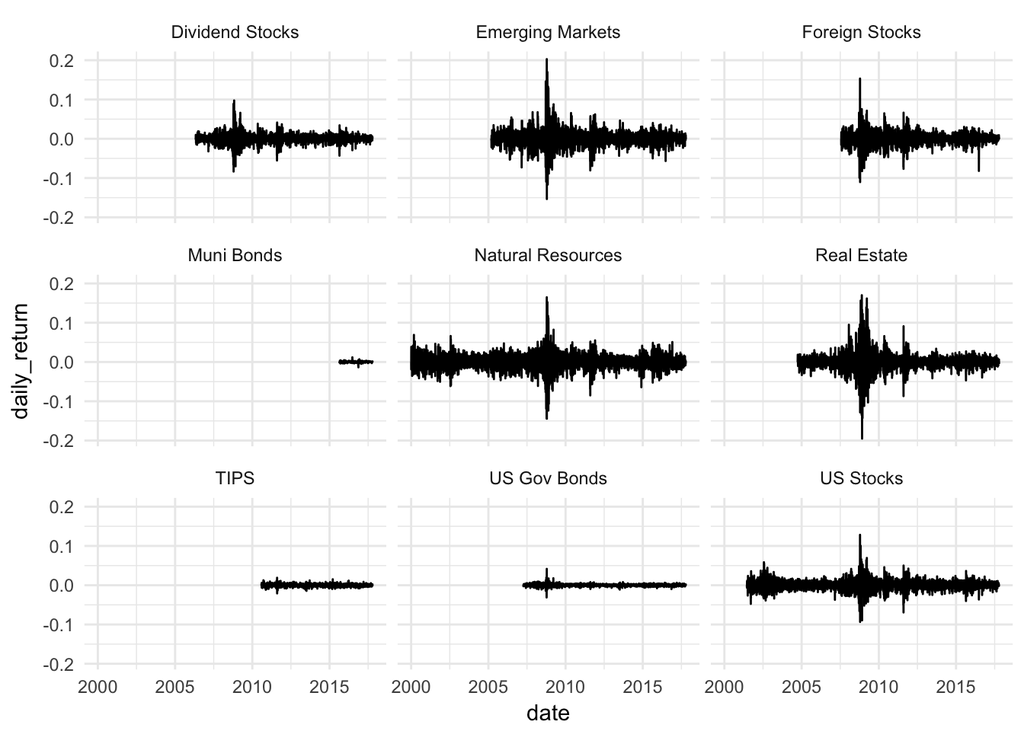

```r
wf_stocks_returns %>%
  ggplot(aes(x = date, y = daily_return)) +
  geom_line() +
  facet_wrap(~wf_name)
```

## Not a complete history for each ticker

```r
wf_stocks_returns %>%
  summarise(min_date = min(date))
```

```
## # A tibble: 9 x 2
##   wf_ticker   min_date
##       <chr>     <date>
## 1       BND 2007-04-10
## 2      SCHP 2010-08-05
## 3       VEA 2007-07-26
## 4       VIG 2006-05-02
## 5       VNQ 2004-09-29
## 6      VTEB 2015-08-25
## 7       VTI 2001-06-15
## 8       VWO 2005-03-10
## 9       XLE 2000-01-03
```

## Throw out VTEB so we at least have history since `2010-08-05`

```r
wf_stocks_returns <- wf_stocks_returns %>%
  filter(wf_ticker != "VTEB")
```

## Now look at the density graphs

Less volatile ETFs have a very narrow, highly peaked density

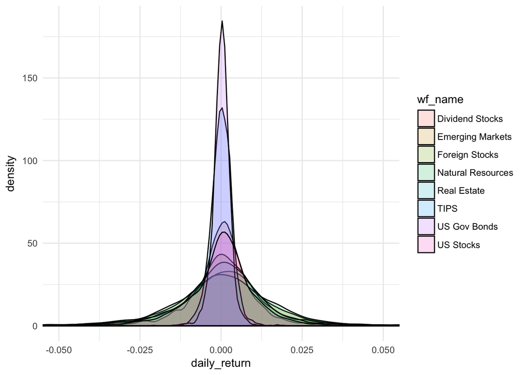

```r
wf_stocks_returns %>%
  ggplot(aes(x = daily_return, fill = wf_name)) +
  geom_density(alpha = .2) +
  theme_minimal() +
  coord_cartesian(xlim = c(-.05, .05))
```

# Portfolio optimization simple cases

## Convert from long to wide

- Also throw out any NA data
- And convert to data.frame only with dates as rownames (for PortfolioAnalytics)

```r
wf_wide_returns <- wf_stocks_returns %>%
  ungroup() %>%
  select(wf_name, date, daily_return) %>%
  spread(wf_name, daily_return) %>%
  as.data.frame() %>%
  na.omit()

rownames(wf_wide_returns) <- wf_wide_returns$date
wf_wide_returns$date <- NULL

head(wf_wide_returns)
```

```
##            Dividend Stocks Emerging Markets Foreign Stocks
## 2010-08-05   -0.0002092673    -0.0034973127   0.0008921446
## 2010-08-06   -0.0031377799    -0.0023397719   0.0029711024
## 2010-08-09    0.0075548131     0.0056286905   0.0026654558
## 2010-08-10   -0.0027076297    -0.0139928793  -0.0070897304
## 2010-08-11   -0.0238096065    -0.0295643980  -0.0467123789
## 2010-08-12   -0.0038510139     0.0009746599  -0.0006242260
##            Natural Resources  Real Estate          TIPS  US Gov Bonds
## 2010-08-05       0.003206757 -0.012566577  0.0000000000  0.0015915641
## 2010-08-06      -0.011898356 -0.004627718  0.0021950774  0.0029341985
## 2010-08-09       0.004133528  0.011429707 -0.0005974277 -0.0012192861
## 2010-08-10      -0.008233403 -0.009768254  0.0057779381  0.0020750987
## 2010-08-11      -0.029777871 -0.024951702  0.0000000000  0.0007311758
## 2010-08-12      -0.005952612 -0.012497833 -0.0061411604 -0.0018255837
##               US Stocks
## 2010-08-05 -0.002083274
## 2010-08-06 -0.003653205
## 2010-08-09  0.005238104
## 2010-08-10 -0.006253059
## 2010-08-11 -0.029540436
## 2010-08-12 -0.005583430
```

## Create a portfolio spec for maximum return no leverage portfolio

```r
pspec <- portfolio.spec(assets = colnames(wf_wide_returns)) %>%
  add.constraint(type = "box", min = 0.00, max = 1.00)

pspec_max_return <- add.objective(pspec, type = "return", name = "mean")

pspec_max_return
```

```
## PortfolioAnalytics Portfolio Specification
##
## Call:
## portfolio.spec(assets = colnames(wf_wide_returns))
##
## Number of assets: 8
## Asset Names
## [1] "Dividend Stocks"   "Emerging Markets"  "Foreign Stocks"
## [4] "Natural Resources" "Real Estate"       "TIPS"
## [7] "US Gov Bonds"      "US Stocks"
##
## Constraints
## Enabled constraint types
##      - box (long only)
##
## Objectives:
## Enabled objective names
##      - mean
```

## Optimize this portfolio

```r
optim_max_return <- optimize.portfolio(R = wf_wide_returns, portfolio = pspec_max_return, optimize_method = "ROI", trace = TRUE)

optim_max_return
```

```
## PortfolioAnalytics Optimization
##
## Call:
## optimize.portfolio(R = wf_wide_returns, portfolio = pspec_max_return,
##     optimize_method = "ROI", trace = TRUE)
##
## Optimal Weights:
##   Dividend Stocks  Emerging Markets    Foreign Stocks Natural Resources
##                 0                 0                 0                 0
##       Real Estate              TIPS      US Gov Bonds         US Stocks
##                 0                 0                 0                 1
##
## Objective Measure:
##      mean
## 0.0005765
```

# Portfolio optimization with purrr in parallel

The whole idea will be to use a “multiple model” framework with purrr and list-columns.

## Setup up efficient frontier tibble

Set up N portfolio specs

- Minimum variance
- Target expected return varies from 0.0001 -> 0.0005764
- “Max return” comes from the max return portfolio above

```r
# Change this to change the number of portfolios that get run
# Increasing this increases the "density" of the frontier line
# because you have more points filling in the gaps
n_portfolios_in_frontier <- 1000

# Vector of target returns for the frontier
min_ret <- 0.0001
max_ret <- optim_max_return$objective_measures$mean
ret_vec <- seq(min_ret, max_ret, length.out = n_portfolios_in_frontier)

frontier <- tibble(return_target = ret_vec)

# A base portfolio spec. Additional constraint will be the return target
# unique to each portfolio spec
# This spec uses no leverage and minimizes variance
base_portfolio_spec <- portfolio.spec(assets = colnames(wf_wide_returns)) %>%
  add.constraint(type = "box", min = 0.00, max = 1.00) %>%
  add.objective(type = "risk", name = "var")

# Function to add target return to the spec
add_return_target_constraint <- function(ret) {
  add.constraint(base_portfolio_spec, type = "return",
                 name = "mean", return_target = ret)
}

# Add a return target constraint to each base spec, and create a list
# column out of them as a new column
frontier <- mutate(frontier,
                   portfolio_spec = map(.x = return_target,
                                        .f = add_return_target_constraint))

frontier
```

```
## # A tibble: 1,000 x 2
##    return_target       portfolio_spec
##            <dbl>               <list>
##  1  0.0001000000 <S3: portfolio.spec>
##  2  0.0001004769 <S3: portfolio.spec>
##  3  0.0001009539 <S3: portfolio.spec>
##  4  0.0001014308 <S3: portfolio.spec>
##  5  0.0001019078 <S3: portfolio.spec>
##  6  0.0001023847 <S3: portfolio.spec>
##  7  0.0001028617 <S3: portfolio.spec>
##  8  0.0001033386 <S3: portfolio.spec>
##  9  0.0001038156 <S3: portfolio.spec>
## 10  0.0001042925 <S3: portfolio.spec>
## # ... with 990 more rows
```

## Slice up the frontier

Slice up frontier into 4 smaller tibbles, each with 250 models to run. These will get distributed across the 4 cores on my machine.

```r
# Groups to divide up what models go to what core on my 4 core machine
future_core <- rep(1:4, each = nrow(frontier) / 4)

# Divide and nest
frontier_divided <- frontier %>%
  mutate(future_core = future_core) %>%
  group_by(future_core) %>%
  nest(.key = "divided_frontier")

frontier_divided
```

```
## # A tibble: 4 x 2
##   future_core   divided_frontier
##         <int>             <list>
## 1           1 <tibble [250 x 2]>
## 2           2 <tibble [250 x 2]>
## 3           3 <tibble [250 x 2]>
## 4           4 <tibble [250 x 2]>
```

## Helper functions for the parallel optimization

1. `optimize_wf_portfolio` will optimize a given portfolio spec
2. `map_optimize` will map the `optimize_wf_portfolio` function to each of the 250 portfolio specs in the sub-tibble

```r
optimize_wf_portfolio <- function(spec) {
  optimize.portfolio(R = wf_wide_returns, portfolio = spec, optimize_method = "ROI")
}

map_optimize <- function(frontier_tbl) {
  mutate(frontier_tbl,
         optimized_model = map(portfolio_spec, optimize_wf_portfolio))
}
```

## Perform the parallel optimization

Each optimized portfolio is returned and is added as an element in a new column in the `frontier` tibble.

- Not in parallel, this takes around `113` seconds on my computer.
- In parallel this takes around `38` seconds.
- Both seem to run slightly faster when not using `Knit to HTML` and instead just running the code chunk by itself. I think future uses a different *plan* when you Knit, but not sure.

```r
# Start time
t1 <- proc.time()

# Tell the future package to use multiprocess
# Picks multicore on Mac, multisession on Windows
plan(multiprocess)

# Send out the computation.
# If running at home, notice how you instantly get control back
# This is due to the future package
frontier_divided <- frontier_divided %>%
  mutate(divided_frontier = map(.x = divided_frontier,
                                .f = ~future(map_optimize(.x))))

# Ask for the results. "Locks up" R until the computations are complete
frontier_divided <- frontier_divided %>%
  mutate(divided_frontier = values(divided_frontier))

# End time
proc.time() - t1
```

```
##    user  system elapsed
##  67.044   0.721  38.070
```

```r
# Unnest and assign back to frontier
frontier <- frontier_divided %>%
  unnest() %>%
  select(-future_core)

frontier
```

```
## # A tibble: 1,000 x 3
##    return_target       portfolio_spec              optimized_model
##            <dbl>               <list>                       <list>
##  1  0.0001000000 <S3: portfolio.spec> <S3: optimize.portfolio.ROI>
##  2  0.0001004769 <S3: portfolio.spec> <S3: optimize.portfolio.ROI>
##  3  0.0001009539 <S3: portfolio.spec> <S3: optimize.portfolio.ROI>
##  4  0.0001014308 <S3: portfolio.spec> <S3: optimize.portfolio.ROI>
##  5  0.0001019078 <S3: portfolio.spec> <S3: optimize.portfolio.ROI>
##  6  0.0001023847 <S3: portfolio.spec> <S3: optimize.portfolio.ROI>
##  7  0.0001028617 <S3: portfolio.spec> <S3: optimize.portfolio.ROI>
##  8  0.0001033386 <S3: portfolio.spec> <S3: optimize.portfolio.ROI>
##  9  0.0001038156 <S3: portfolio.spec> <S3: optimize.portfolio.ROI>
## 10  0.0001042925 <S3: portfolio.spec> <S3: optimize.portfolio.ROI>
## # ... with 990 more rows
```

# Post analysis

## Model metrics

Some initial models cannot hit the arbitrary low return target I had specified.

```r
# Calculate model metrics for each optimization
frontier <- frontier %>%
 mutate(weights       = map(.x = optimized_model,     .f = ~.x$weights),
        actual_risk   = map_dbl(.x = optimized_model, .f = ~.x$objective_measures$StdDev),
        actual_return = map_dbl(.x = weights,         .f = ~.x %*% colMeans(wf_wide_returns)),
        actual_sharpe = actual_return / actual_risk)

# Print as a paged data frame
rmarkdown:::print.paged_df(frontier)
```

| return_target | portfolio_spec | optimized_model | weights | actual_risk | actual_return | actual_sharpe |
| --- | --- | --- | --- | --- | --- | --- |
| 0.0001000000 |  |  |  | NA | NA | NA |
| 0.0001004769 |  |  |  | NA | NA | NA |
| 0.0001009539 |  |  |  | NA | NA | NA |
| 0.0001014308 |  |  |  | NA | NA | NA |
| 0.0001019078 |  |  |  | NA | NA | NA |
| 0.0001023847 |  |  |  | NA | NA | NA |
| 0.0001028617 |  |  |  | NA | NA | NA |
| 0.0001033386 |  |  |  | NA | NA | NA |
| 0.0001038156 |  |  |  | NA | NA | NA |
| 0.0001042925 |  |  |  | NA | NA | NA |

[output cut: 990 more lines]

## A nice ggplot of the frontier

Lighter color for higher sharpe ratio.

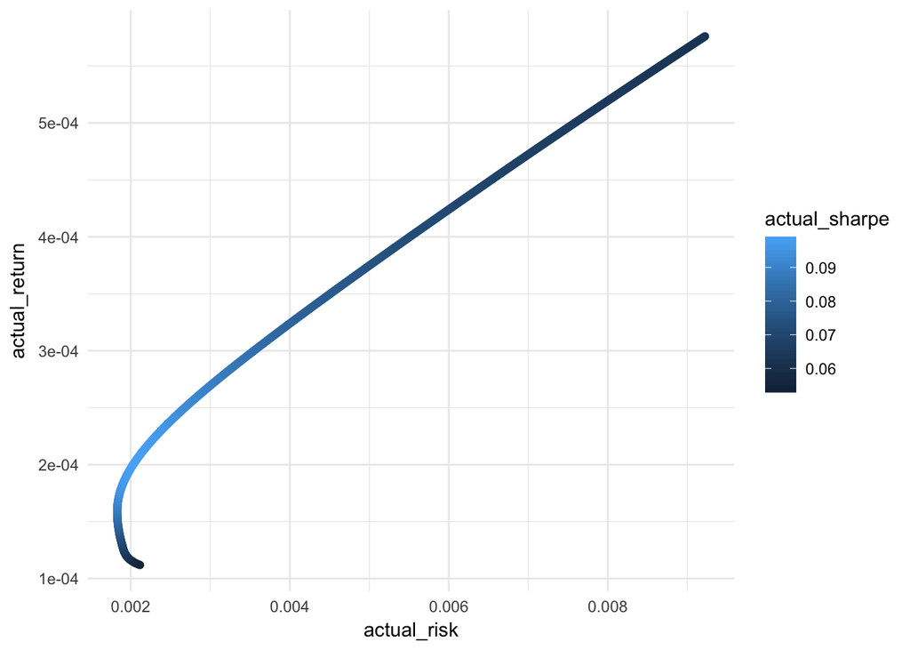

```r
ggplot(frontier, aes(x = actual_risk, y = actual_return, color = actual_sharpe)) +
  geom_point()
```

## Best portfolios as defined by max sharpe and return

```r
# "Best" as defined by max sharpe
frontier %>%
  filter(actual_sharpe == max(actual_sharpe, na.rm = TRUE)) %>%
  summarise(annual_risk = actual_risk * sqrt(252),
            annual_ret  = (actual_return + 1) ^ 252 - 1)
```

```
## # A tibble: 1 x 2
##   annual_risk annual_ret
##         <dbl>      <dbl>
## 1  0.03290869 0.05286669
```

```r
# "Best" as defined by max return
frontier %>%
  filter(actual_return == max(actual_return, na.rm = TRUE)) %>%
  summarise(annual_risk = actual_risk * sqrt(252),
            annual_ret  = (actual_return + 1) ^ 252 - 1)
```

```
## # A tibble: 1 x 2
##   annual_risk annual_ret
##         <dbl>      <dbl>
## 1   0.1463892  0.1561657
```